# Scraping_Coingeko_and_Markowitz_optimization

## 3- Main Code to evaluate the allocation considering the return and the volatility

### Cryptocurrency Data Analysis Script

#### Dependencies

- `pycoingecko`: A Python wrapper for the CoinGecko API.
- `pandas`: A library providing high-performance, easy-to-use data structures and data analysis tools.
- `numpy`: A library for the Python programming language, adding support for large, multi-dimensional arrays and matrices, along with a large collection of high-level mathematical functions to operate on these arrays.
- `datetime`: Standard Python library for manipulating dates and times.
- `scipy.optimize`: A module in SciPy which provides functions for minimizing (or maximizing) objective functions, possibly subject to constraints.

#### Core Components

1. **API Initialization**:
   - Initializes the CoinGecko API for fetching cryptocurrency data.
2. **Cryptocurrency Identifiers**:
   - Defines a dictionary `crypto_ids` with the names and CoinGecko identifiers of the selected cryptocurrencies.
3. **Current Prices Retrieval**:
   - Fetches the current prices of the specified cryptocurrencies in euros.
4. **Historical Data Function (`get_historical_data`)**:
   - A function to retrieve historical price data and calculate the mean return and volatility for a given cryptocurrency.
5. **Data Aggregation**:
   - Retrieves historical data for each cryptocurrency and stores the results.
6. **DataFrame Creation**:
   - Compiles the retrieved data into a pandas DataFrame for analysis and visualization.

#### Usage

1. Define the cryptocurrencies you want to analyze by modifying the `crypto_ids` dictionary.
2. Run the script to retrieve current prices, historical data, mean returns, and volatilities.
3. The resulting pandas DataFrame `df_crypto` contains this information for each cryptocurrency.

#### Example

The DataFrame `df_crypto` includes columns for `crypto_id`, `current_price`, `mean_return`, and `volatility` for each specified cryptocurrency.

#### Note

Ensure you have the required dependencies installed and a working internet connection to fetch data from the CoinGecko API.

```python
from pycoingecko import CoinGeckoAPI
import pandas as pd
import numpy as np
from datetime import datetime, timedelta
from scipy.optimize import minimize

# Initialisation de l'API CoinGecko
cg = CoinGeckoAPI()

# Identifiants CoinGecko des cryptomonnaies spécifiées
crypto_ids = {
    "SingularityNET": "singularitynet",
    "LCX": "lcx",
    "Syncus": "syncus",
    "Avalanche" :"avalanche-2",
}

# Récupération des prix actuels
current_prices = {crypto: cg.get_price(ids=id_, vs_currencies='eur')[id_]['eur'] for crypto, id_ in crypto_ids.items()}

# Fonction pour calculer le rendement moyen et la volatilité
def get_historical_data(crypto_id):
    end_date = datetime.now()
    default_start_date = end_date - timedelta(days=365)  # Date de début par défaut

    # Récupération de la date de création de la cryptomonnaie
    coin_data = cg.get_coin_by_id(id=crypto_id)
    genesis_date_str = coin_data.get('genesis_date')

    # Vérifier si la date de création est disponible
    if genesis_date_str:
        try:
            start_date = datetime.fromtimestamp(int(genesis_date_str))
        except ValueError:
            start_date = datetime.strptime(genesis_date_str, "%Y-%m-%d")
    else:
        start_date = default_start_date

    # Utilisation de la date de début par défaut si la monnaie existe depuis moins de 365 jours
    if start_date > end_date - timedelta(days=365):
        start_date = default_start_date

    historical_data = cg.get_coin_market_chart_range_by_id(id=crypto_id,
                                                          vs_currency='eur',
                                                          from_timestamp=start_date.timestamp(),
                                                          to_timestamp=end_date.timestamp())
    prices = [p[1] for p in historical_data['prices']]
    returns = np.diff(prices) / prices[:-1]
    mean_return = np.mean(returns)
    volatility = np.std(returns)
    return mean_return, volatility

# Récupération des rendements et volatilités
historical_data = {id_: get_historical_data(id_) for id_ in crypto_ids.values()}

# Création du DataFrame
df_crypto = pd.DataFrame({
    "crypto_id": list(crypto_ids.keys()),
    "current_price": list(current_prices.values()),
    "mean_return": [data[0] for data in historical_data.values()],
    "volatility": [data[1] for data in historical_data.values()]
})
```

# # 4- Cryptocurrency Portfolio Optimization Script

#### Description

This script is designed to optimize a cryptocurrency investment portfolio. It calculates the optimal allocation of different cryptocurrencies to maximize the Sharpe ratio, a measure of risk-adjusted return.

#### Dependencies

- `matplotlib.pyplot`: A plotting library used for creating graphs and charts in Python.
- `numpy`: Used for numerical calculations.
- `scipy.optimize`: Provides a method for function optimization.

#### Core Components

1. **Portfolio Return Calculation**:
   - A function to calculate the expected return of the portfolio based on asset weights and individual returns.
2. **Portfolio Volatility Calculation**:
   - A function to calculate the portfolio's volatility using the weights of the assets and the covariance matrix.
3. **Negative Sharpe Ratio Calculation**:
   - A function to calculate the negative Sharpe ratio, used for maximizing the Sharpe ratio through optimization.
4. **Covariance Matrix Creation**:
   - Generates a covariance matrix from the volatilities of the cryptocurrencies.
5. **Optimization Setup**:
   - Defines constraints, bounds, and initial guess for the optimization process.
6. **Optimization Execution**:
   - Uses the `minimize` function from `scipy.optimize` to find the portfolio allocation that maximizes the Sharpe ratio.
7. **Results Display**:
   - Prints the optimal weights, expected return, expected volatility, and Sharpe ratio of the optimized portfolio.
8. **Portfolio Visualization**:
   - Creates a pie chart to visualize the distribution of assets in the optimized portfolio.

#### Usage

1. Ensure that `df_crypto` DataFrame is available with necessary data (`mean_return` and `volatility` for each cryptocurrency).
2. Run the script to perform portfolio optimization.
3. View the printed results and the pie chart for asset allocation.

#### Example

The output includes the optimal asset weights in the portfolio, the expected portfolio return, the expected portfolio volatility, and the Sharpe ratio. A pie chart represents the percentage allocation of each cryptocurrency in the optimized portfolio.

#### Note

This script assumes that the `df_crypto` DataFrame is correctly structured and contains relevant data for the cryptocurrencies under consideration. Adjust the DataFrame structure as needed to match your data.

```
Pondérations optimales: [0.01753511 0.01603898 0.95228283 0.01414309]
Rendement attendu: 0.24669901140617326
Volatilité attendue: 0.3511016707247342
Ratio de Sharpe: 0.7026426587402563
```

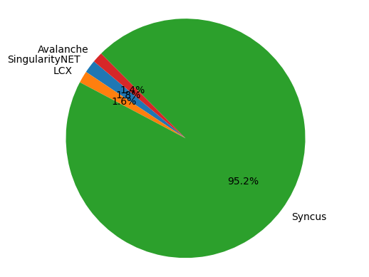

```python
import matplotlib.pyplot as plt

# Fonction pour calculer le rendement du portefeuille
def portfolio_return(weights, returns):
    return np.dot(weights, returns)

# Fonction pour calculer la volatilité du portefeuille
def portfolio_volatility(weights, cov_matrix):
    return np.sqrt(np.dot(weights.T, np.dot(cov_matrix, weights)))

# Fonction pour calculer le ratio de Sharpe négatif (pour minimiser dans l'optimisation)
def negative_sharpe_ratio(weights, returns, cov_matrix, risk_free_rate=0.0):
    p_ret = portfolio_return(weights, returns)
    p_vol = portfolio_volatility(weights, cov_matrix)
    return -(p_ret - risk_free_rate) / p_vol

# Création de la matrice de covariance
cov_matrix = df_crypto['volatility'].cov(df_crypto['volatility'])

# Contraintes (la somme des poids doit être 1)
constraints = ({'type': 'eq', 'fun': lambda x: np.sum(x) - 1})

# Bornes pour chaque poids (entre 0 et 1)
bounds = tuple((0, 1) for _ in range(len(df_crypto)))

# Initialisation des poids (distribution uniforme)
init_guess = [1.0/len(df_crypto)]*len(df_crypto)

# Optimisation pour maximiser le ratio de Sharpe
opt_result = minimize(negative_sharpe_ratio, init_guess,
                      args=(df_crypto['mean_return'], cov_matrix),
                      method='SLSQP', bounds=bounds, constraints=constraints)

# Affichage des résultats
print("Pondérations optimales:", opt_result.x)
print("Rendement attendu:", portfolio_return(opt_result.x, df_crypto['mean_return']))
print("Volatilité attendue:", portfolio_volatility(opt_result.x, cov_matrix))
print("Ratio de Sharpe:", -negative_sharpe_ratio(opt_result.x, df_crypto['mean_return'], cov_matrix))

# Tracer le graphique du portefeuille
labels = df_crypto['crypto_id']
sizes = opt_result.x * 100  # Conversion en pourcentages

fig1, ax1 = plt.subplots()
ax1.pie(sizes, labels=labels, autopct='%1.1f%%', startangle=140)
ax1.axis('equal')  # Equal aspect ratio ensures that pie is drawn as a circle.
plt.show()
```

## 5-Efficient Frontier Simulation in Cryptocurrency Portfolio Optimization

### Efficient Frontier Simulation in Cryptocurrency Portfolio Optimization

#### Description

This script simulates a multitude of cryptocurrency portfolios to visualize the efficient frontier. This concept in portfolio theory highlights the set of optimal portfolios offering the highest expected return for a given level of risk.

#### Dependencies

- `matplotlib.pyplot`: A plotting library for creating graphs and charts in Python.
- `numpy`: Used for numerical calculations.

#### Core Components

1. **Portfolio Simulation Parameters**:
   - Sets the number of portfolios to simulate and initializes arrays to store weights, returns, volatilities, and Sharpe ratios.
2. **Portfolio Simulation Loop**:
   - Randomly generates portfolio weights for each simulation.
   - Calculates expected return, volatility, and Sharpe ratio for each portfolio.
3. **Efficient Frontier Visualization**:
   - Plots each simulated portfolio on a scatter plot with volatility on the x-axis and expected return on the y-axis.
   - Color-codes each point based on its Sharpe ratio, providing a visual representation of risk-adjusted returns.
4. **Highlighting the Optimal Portfolio**:
   - Identifies and marks the portfolio with the highest Sharpe ratio, indicating the most efficient portfolio in the simulation.

#### Usage

1. Ensure the required data (mean returns, volatilities) is available in `df_crypto` DataFrame.
2. Run the script to perform the simulation and plot the efficient frontier.
3. Analyze the plotted graph to understand the trade-off between risk (volatility) and expected return.

#### Visualization

- The scatter plot displays the efficient frontier. Each point represents a different portfolio composition.
- The color intensity represents the Sharpe ratio, indicating how well the return compensates for the risk.
- The portfolio with the best Sharpe ratio is highlighted, showing the most desirable risk-return balance.

#### Note

This script assumes that the `df_crypto` DataFrame and previously defined functions (`portfolio_return`, `portfolio_volatility`) are available. The simulation relies on the accuracy and relevance of the input data.

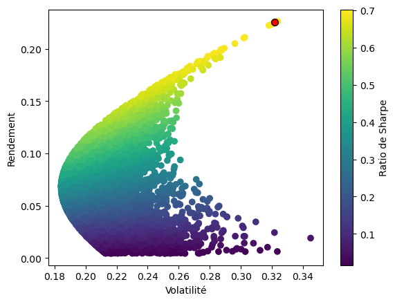

```python
# Nombre de portefeuilles à simuler pour la frontière efficiente
num_portfolios = 10000
all_weights = np.zeros((num_portfolios, len(df_crypto)))
ret_arr = np.zeros(num_portfolios)
vol_arr = np.zeros(num_portfolios)
sharpe_arr = np.zeros(num_portfolios)

for i in range(num_portfolios):
    # Générer des poids aléatoires
    weights = np.random.random(len(df_crypto))
    weights /= np.sum(weights)

    # Sauvegarder les poids
    all_weights[i, :] = weights

    # Rendement attendu
    ret_arr[i] = portfolio_return(weights, df_crypto['mean_return'])

    # Volatilité
    vol_arr[i] = portfolio_volatility(weights, cov_matrix)

    # Ratio de Sharpe
    sharpe_arr[i] = ret_arr[i] / vol_arr[i]

# Tracer la frontière efficiente
plt.scatter(vol_arr, ret_arr, c=sharpe_arr, cmap='viridis')
plt.colorbar(label='Ratio de Sharpe')
plt.xlabel('Volatilité')
plt.ylabel('Rendement')

# Marquer le portefeuille avec le meilleur ratio de Sharpe
max_sr_ret = ret_arr[sharpe_arr.argmax()]
max_sr_vol = vol_arr[sharpe_arr.argmax()]
plt.scatter(max_sr_vol, max_sr_ret, c='red', s=50, edgecolors='black')

# Afficher le graphique
plt.show()
```